# Clustering_Bank

Background:

AllLife Bank wants to focus on its credit card customer base in the next financial year. They have been advised by their marketing research team, that the penetration in the market can be improved. Based on this input, the Marketing team proposes to run personalised campaigns to target new customers as well as upsell to existing customers. Another insight from the market research was that the customers perceive the support services of the back poorly. Based on this, the Operations team wants to upgrade the service delivery model, to ensure that customers queries are resolved faster. Head of Marketing and Head of Delivery both decide to reach out to the Data Science team for help.Objective: To identify different segments in the existing customer based on their spending patterns as well as past interaction with the bank.

# Key Questions: 1.How many different segments of customers are there? 2.How are these segments different from each other? 3.What are your recommendations to the bank on how to better market to and service these customers?

```python
# import necessary libraries
import numpy as np
import pandas as pd
import matplotlib.pyplot as plt
import seaborn as sns

from sklearn.preprocessing import StandardScaler
from sklearn.decomposition import PCA
from scipy.stats import zscore

import warnings
warnings.filterwarnings(action="ignore")

# for clustering
from sklearn.cluster import KMeans, AgglomerativeClustering
from sklearn.mixture import GaussianMixture
from matplotlib import cm
from sklearn.metrics import silhouette_samples, silhouette_score

from scipy.stats import zscore
from scipy.spatial.distance import pdist, squareform
from scipy.cluster.hierarchy import linkage, dendrogram, cut_tree
import matplotlib.pyplot as plt
```

```python
# load  data
cust_data = pd.read_excel('Credit Card Customer Data.xlsx')
```

```python
cust_data.head()
```

|  | Sl_No | Customer Key | Avg_Credit_Limit | Total_Credit_Cards | Total_visits_bank | Total_visits_online | Total_calls_made |
| --- | --- | --- | --- | --- | --- | --- | --- |
| 0 | 1 | 87073 | 100000 | 2 | 1 | 1 | 0 |
| 1 | 2 | 38414 | 50000 | 3 | 0 | 10 | 9 |
| 2 | 3 | 17341 | 50000 | 7 | 1 | 3 | 4 |
| 3 | 4 | 40496 | 30000 | 5 | 1 | 1 | 4 |
| 4 | 5 | 47437 | 100000 | 6 | 0 | 12 | 3 |

# Checking the data

```python
cust_data.shape
```

```
(660, 7)
```

```python
#Describe the data
cust_data.describe().transpose()
```

|  | count | mean | std | min | 25% | 50% | 75% | max |
| --- | --- | --- | --- | --- | --- | --- | --- | --- |
| Sl_No | 660.0 | 330.500000 | 190.669872 | 1.0 | 165.75 | 330.5 | 495.25 | 660.0 |
| Customer Key | 660.0 | 55141.443939 | 25627.772200 | 11265.0 | 33825.25 | 53874.5 | 77202.50 | 99843.0 |
| Avg_Credit_Limit | 660.0 | 34574.242424 | 37625.487804 | 3000.0 | 10000.00 | 18000.0 | 48000.00 | 200000.0 |
| Total_Credit_Cards | 660.0 | 4.706061 | 2.167835 | 1.0 | 3.00 | 5.0 | 6.00 | 10.0 |
| Total_visits_bank | 660.0 | 2.403030 | 1.631813 | 0.0 | 1.00 | 2.0 | 4.00 | 5.0 |
| Total_visits_online | 660.0 | 2.606061 | 2.935724 | 0.0 | 1.00 | 2.0 | 4.00 | 15.0 |
| Total_calls_made | 660.0 | 3.583333 | 2.865317 | 0.0 | 1.00 | 3.0 | 5.00 | 10.0 |

```python
#check for NA and null
cust_data.isna().sum()
```

```
Sl_No                  0
Customer Key           0
Avg_Credit_Limit       0
Total_Credit_Cards     0
Total_visits_bank      0
Total_visits_online    0
Total_calls_made       0
dtype: int64
```

```python
cust_data.isnull().sum()
```

```
Sl_No                  0
Customer Key           0
Avg_Credit_Limit       0
Total_Credit_Cards     0
Total_visits_bank      0
Total_visits_online    0
Total_calls_made       0
dtype: int64
```

```python
cust_data.dtypes
# All data seems to be integer values
```

```
Sl_No                  int64
Customer Key           int64
Avg_Credit_Limit       int64
Total_Credit_Cards     int64
Total_visits_bank      int64
Total_visits_online    int64
Total_calls_made       int64
dtype: object
```

```python
# Serial number and Cust Key can be filtered out
credit_data_new = cust_data.iloc[:,2:]
credit_data_new
```

|  | Avg_Credit_Limit | Total_Credit_Cards | Total_visits_bank | Total_visits_online | Total_calls_made |
| --- | --- | --- | --- | --- | --- |
| 0 | 100000 | 2 | 1 | 1 | 0 |
| 1 | 50000 | 3 | 0 | 10 | 9 |
| 2 | 50000 | 7 | 1 | 3 | 4 |
| 3 | 30000 | 5 | 1 | 1 | 4 |
| 4 | 100000 | 6 | 0 | 12 | 3 |
| ... | ... | ... | ... | ... | ... |
| 655 | 99000 | 10 | 1 | 10 | 0 |
| 656 | 84000 | 10 | 1 | 13 | 2 |
| 657 | 145000 | 8 | 1 | 9 | 1 |
| 658 | 172000 | 10 | 1 | 15 | 0 |
| 659 | 167000 | 9 | 0 | 12 | 2 |

660 rows × 5 columns

# Univariate and Multivariate Analysis

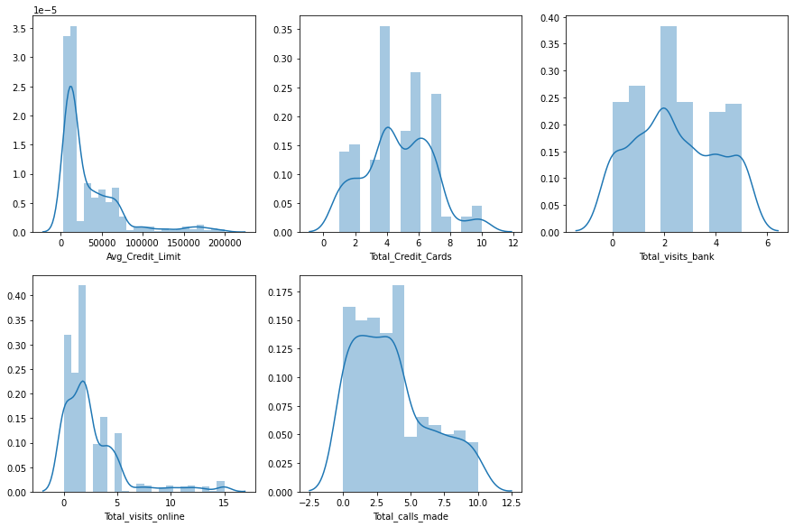

```python
# scan through the columns via for loop
# Avg Credit Limit is slightly skewed and it could be expected as some customers with more credit limit can exist.
plt.figure(figsize=(15,15))
pos = 1
for i in credit_data_new.columns:
    plt.subplot(3, 3, pos)
    sns.distplot(cust_data[i])
    pos += 1
```

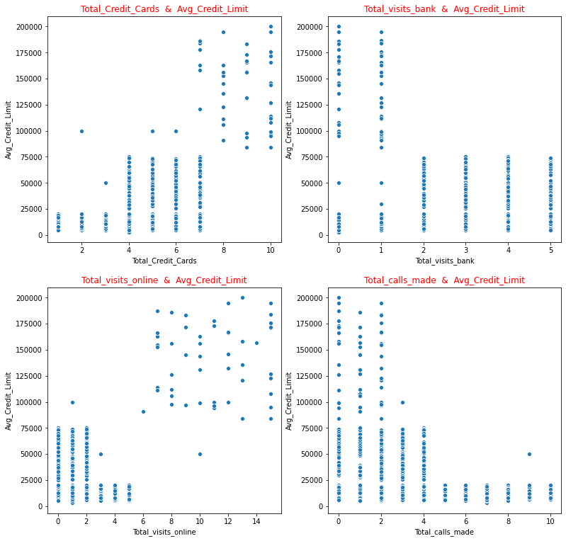

```python
# Create scatter plots ....
# Some observations : Customer with higher credit limits(>75000) have more credit cards
import itertools
cols = [i for i in credit_data_new.columns if i not in 'Avg_Credit_Limit']
length = len(cols)

plt.figure(figsize=(13,27))
for i,j in itertools.zip_longest(cols,range(length)):
    plt.subplot(4,2,j+1)
    sns.scatterplot(cust_data[i], credit_data_new["Avg_Credit_Limit"])
    plt.title(i+"  &  Avg_Credit_Limit",color="red")
```

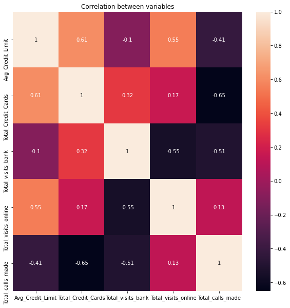

```python
# Corelation between variables
# Avg Credit Limit and Total Credit cards seem to be corelated to some extent..
plt.figure(figsize = (10,10))
sns.heatmap(credit_data_new.corr(method = 'pearson'), annot = True)
plt.title("Correlation between variables")
```

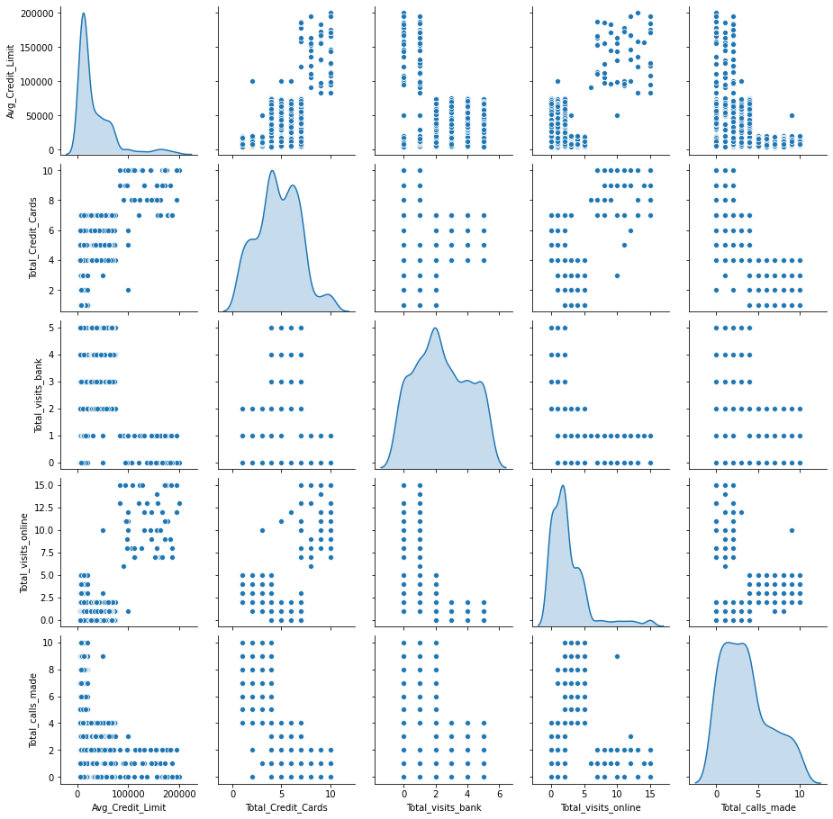

```python
# observe pair plot
sns.pairplot(credit_data_new,diag_kind='kde')
```

```python
credit_data_new.head()
```

|  | Avg_Credit_Limit | Total_Credit_Cards | Total_visits_bank | Total_visits_online | Total_calls_made |
| --- | --- | --- | --- | --- | --- |
| 0 | 100000 | 2 | 1 | 1 | 0 |
| 1 | 50000 | 3 | 0 | 10 | 9 |
| 2 | 50000 | 7 | 1 | 3 | 4 |
| 3 | 30000 | 5 | 1 | 1 | 4 |
| 4 | 100000 | 6 | 0 | 12 | 3 |

```python
# We need to scale the data so that Avg Credit limit does not skew the data ... use zscore

data_credit_scaled = credit_data_new.apply(zscore)
data_credit_scaled.shape
```

```
(660, 5)
```

```python
data_credit_scaled.head()
```

|  | Avg_Credit_Limit | Total_Credit_Cards | Total_visits_bank | Total_visits_online | Total_calls_made |
| --- | --- | --- | --- | --- | --- |
| 0 | 1.740187 | -1.249225 | -0.860451 | -0.547490 | -1.251537 |
| 1 | 0.410293 | -0.787585 | -1.473731 | 2.520519 | 1.891859 |
| 2 | 0.410293 | 1.058973 | -0.860451 | 0.134290 | 0.145528 |
| 3 | -0.121665 | 0.135694 | -0.860451 | -0.547490 | 0.145528 |
| 4 | 1.740187 | 0.597334 | -1.473731 | 3.202298 | -0.203739 |